# R Notebook

Use the Peruvian data, and prepare a code in R to answer: - Is the whole network connected? If disconnected, keep the giant component to answer all the remaining questions. If connected, use the whole graph for the remaining questions. - Who are the nodes that represent the vertices in the diameter? - Make a plot that highlights the nodes with the highest betweenness. - Make a DataFrame with three the centrality measures, and plot those three values in a scatterplot.

```r
rm(list = ls())
GitLink='https://github.com/DACSS690C-CSSMETHODS/HW2/raw/refs/heads/main/graph_FigueData.graphml'
```

```r
library(igraph)
peru=read_graph(GitLink,format='graphml')
```

```r
summary(peru)
```

```
## IGRAPH 4664573 D-W- 37 266 --
## + attr: Multinacional (v/n), id (v/c), weight (e/n)
```

This is a summary of my directed (D) weighted (W) graph, with 37 nodes and 266 edges.

Adding names to my nodes:

```r
V(peru)$name=V(peru)$id
```

Question 1: Is the whole network connected? If disconnected, keep the giant component to answer all the remaining questions. If connected, use the whole graph for the remaining questions.

```r
is_connected(peru)
```

```
## [1] FALSE
```

It looks like the network is disconnected.

Question 2: Who are the nodes that represent the vertices in the diameter?

Option A method:

```r
isolates = which(degree(peru,mode='in') + degree(peru,mode='out')==0 )
peru_noIsolates = delete_vertices(peru, isolates)
## result
summary(peru_noIsolates)
```

```
## IGRAPH 82f54de DNW- 31 266 --
## + attr: Multinacional (v/n), id (v/c), name (v/c), weight (e/n)
```

Now I can find nodes that represent the vertices in the diameter

```r
diameter(peru_noIsolates)
```

```
## [1] 4
```

The diameter of a graph is the length of the longest shortest path between any two vertices. The output shows that the diameter is 4.

```r
farthest_vertices(peru_noIsolates)
```

```
## $vertices
## + 2/31 vertices, named, from 82f54de:
## [1] Michell Wong Lu
##
## $distance
## [1] 4
```

Finding the nodes whose geodesic represent the diameter: Michell and Wong Lu

```r
get_diameter(peru_noIsolates)
```

```
## + 5/31 vertices, named, from 82f54de:
## [1] Michell      Miro Quesada Romero       Bentin       Wong Lu
```

The nodes that represent the vertices in the diameter of the graph peru_noIsolates are: Vertices: Michell Miro Quesada Romero Bentin Wong Lu  
These vertices form the longest shortest path in the graph, which has a length of 4.

Question 3: Make a plot that highlights the nodes with the highest betweenness.

```r
sort(betweenness(peru_noIsolates,normalized=T))
```

```
##       Benavides         Michell         Wong Lu  Matos Escalada          Galsky
##    0.0000000000    0.0000000000    0.0000000000    0.0000000000    0.0000000000
##  Woodman Pollit         Brescia Batievsky Spack        Cilloniz       Ferreyros
##    0.0004433498    0.0006343943    0.0022988506    0.0025596817    0.0034614427
##          Picaso          Piazza        Nicolini           Raffo     Rizo Patron
##    0.0035982790    0.0051768347    0.0053174603    0.0057218738    0.0062944718
##         Onrubia Beoutis Ledesma         Montori    Llosa Barber       Sotomayor
##    0.0066774125    0.0085509497    0.0113409962    0.0116008119    0.0116570881
##           Wiese         Montero     Berckemeyer    De La Puente           Graña
##    0.0143752618    0.0199852638    0.0264479612    0.0320236955    0.0351292766
##    Miro Quesada      Bustamante         Moreyra          Romero          Bentin
##    0.0351292766    0.0468814134    0.0532509353    0.0854937107    0.0884913456
##            Fort
##    0.1291821006
```

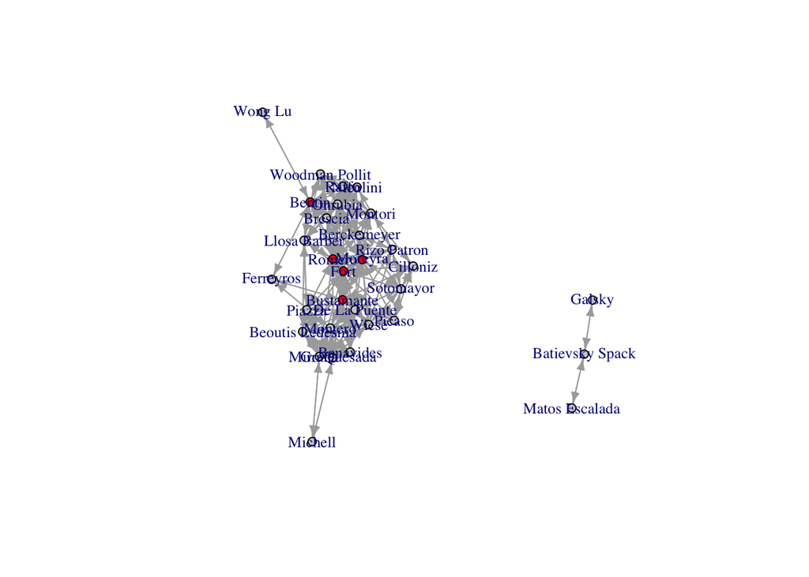

```r
#getting betweenness centrality for all nodes and sort it
betweenness_scores = betweenness(peru_noIsolates, directed = TRUE, weights = E(peru_noIsolates)$weight, normalized = TRUE)
sorted_betweenness_scores = sort(betweenness_scores, decreasing = TRUE)

#defining a threshold for top betweenness nodes
top_n = 5
top_betweenness_threshold = sorted_betweenness_scores[top_n]

#indentifying the nodes with the highest betweenness centrality
top_betweenness_nodes = V(peru_noIsolates)[betweenness_scores >= top_betweenness_threshold]

#colors
vcol = rep("grey80", vcount(peru_noIsolates))
vcol[top_betweenness_nodes] = "red"

#plotting
plot(peru_noIsolates, vertex.color = vcol, layout = layout.fruchterman.reingold,
     vertex.label.cex = 0.8, vertex.size = 5, edge.arrow.size = 0.5)
```

Question 4: Make a DataFrame with three the centrality measures, and plot those three values in a scatterplot.

```r
#three the centrality measures
rounding=2
degr=round(degree(peru_noIsolates,normalized=T),rounding)
close=round(closeness(peru_noIsolates,normalized=T),rounding)
betw=round(betweenness(peru_noIsolates,normalized=T),rounding)
#making the dataframe
DFCentrality=as.data.frame(cbind(degr,close,betw),stringsAsFactors = F)
names(DFCentrality)=c('Degree','Closeness','Betweenness')
```

```r
DFCentrality$person=row.names(DFCentrality)
row.names(DFCentrality)=NULL
```

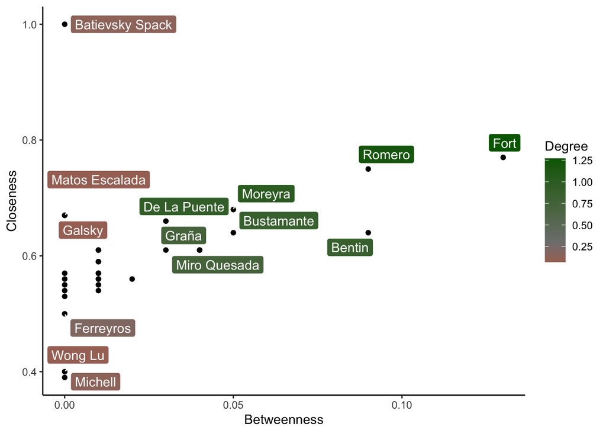

```r
#plotting scatterplot
library(ggplot2)
library(ggrepel)
ggplot(DFCentrality, aes(x=Betweenness, y=Closeness)) +
    theme_classic() + geom_point() +
    geom_label_repel(aes(label=person,fill=Degree),color='white') +
    scale_fill_gradient2(low = "red", mid='grey50',high ="darkgreen",
                           midpoint = 0.3)
```

Use the Seattle data, and prepare a code in R to answer: - Is the whole network connected? If disconnected, keep the giant component to answer all the remaining questions. If connected, use the whole graph for the remaining questions. - How many nodes should be deleted to split this network? - Make a DataFrame with three the Link Analysis measures Hubs, Authorities, and PageRank, and plot those three values in a scatterplot.

```r
rm(list = ls())
GitLink='https://github.com/DACSS690C-CSSMETHODS/HW2/raw/refs/heads/main/graph_edgelist.graphml'
```

```r
library(igraph)
seattle=read_graph(GitLink,format='graphml')
```

```r
summary(seattle)
```

```
## IGRAPH 952eede D-W- 46 588 --
## + attr: male (v/n), followers (v/n), id (v/c), weight (e/n)
```

This is a summary of my directed (D) weighted (W) graph, with 46 nodes and 588 edges.

Adding names to my nodes:

```r
V(seattle)$name=V(seattle)$id
```

Question 1: Is the whole network connected? If disconnected, keep the giant component to answer all the remaining questions. If connected, use the whole graph for the remaining questions.

```r
is_connected(seattle)
```

```
## [1] TRUE
```

It looks like the network is connected.

Question 2: How many nodes should be deleted to split this network?

```r
vertex_connectivity(seattle)
```

```
## [1] 0
```

0 nodes should be deleted.

Question 3: Make a DataFrame with three the Link Analysis measures Hubs, Authorities, and PageRank, and plot those three values in a scatterplot.

```r
#my three link analysis measures
Lk_hub=hub_score(seattle)$vector
Lk_auth=authority_score(seattle)$vector
Lk_page=page_rank(seattle)$vector
#making the dataframe
seattle_LINK=as.data.frame(cbind(Lk_hub,Lk_auth,Lk_page))
seattle_LINK
```

|  | Lk_hub | Lk_auth | Lk_page |
| --- | --- | --- | --- |
| rachelerman | 0.79229427 | 0.82690110 | 0.041300710 |
| mattmcilwain | 0.29237208 | 0.50775270 | 0.021471817 |
| DaveParkerSEA | 0.96185384 | 0.59677221 | 0.021020399 |
| toddbishop | 1.00000000 | 1.00000000 | 0.048877873 |
| ashannstew | 0.53118533 | 0.53733608 | 0.016190719 |
| LeslieFeinzaig | 0.51698752 | 0.76562480 | 0.024664103 |
| akipman | 0.01840499 | 0.20633148 | 0.014519062 |
| matt_oppy | 0.81294068 | 0.46247128 | 0.018805531 |
| gilbert | 0.23517500 | 0.64273953 | 0.024511684 |
| juliesandler | 0.81840871 | 0.89718509 | 0.038981657 |

[output cut: 36 more lines]

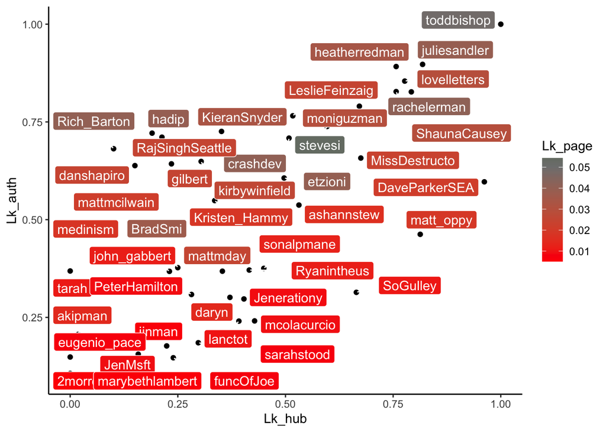

```r
#scatterplot time
seattle_LINK$person=row.names(seattle_LINK)

ggplot(seattle_LINK, aes(x=Lk_hub, y=Lk_auth)) +
    theme_classic() + geom_point() +
    geom_label_repel(aes(label=person,fill=Lk_page),color='white') +
    scale_fill_gradient2(low = "red", mid='grey50',high ="darkgreen",
                           midpoint = 0.05)
```

Use the Fifa Data, projecting only the countries, and report: - Is the whole network connected? If disconnected, keep the giant component to answer all the remaining questions. If connected, use the whole graph for the remaining questions. - What is the density of this network? - Make a DataFrame with three the centrality measures, and plot those three values in a scatterplot.

```r
rm(list = ls())
GitLink='https://github.com/DACSS690C-CSSMETHODS/HW2/raw/refs/heads/main/country_projection.graphml'
```

```r
library(igraph)
fifa=read_graph(GitLink,format='graphml')
```

```r
summary(fifa)
```

```
## IGRAPH 1ef51f0 U--- 32 305 --
## + attr: bipartite (v/n), id (v/c)
```

This is a summary of my undirected graph, with 32 nodes and 305 edges.

Adding names to my nodes:

```r
V(fifa)$name=V(fifa)$id
```

Question 1: Is the whole network connected? If disconnected, keep the giant component to answer all the remaining questions. If connected, use the whole graph for the remaining questions.

```r
is_connected(fifa)
```

```
## [1] TRUE
```

It looks like the network is connected.

Question 2: What is the density of this network?

```r
edge_density(fifa)
```

```
## [1] 0.6149194
```

Question 3: Make a DataFrame with three the centrality measures, and plot those three values in a scatterplot.

```r
#my three centrality measures
rounding=2
degr=round(degree(fifa,normalized=T),rounding)
close=round(closeness(fifa,normalized=T),rounding)
betw=round(betweenness(fifa,normalized=T),rounding)
#making the dataframe
DFCentrality=as.data.frame(cbind(degr,close,betw),stringsAsFactors = F)
names(DFCentrality)=c('Degree','Closeness','Betweenness')
```

```r
DFCentrality$person=row.names(DFCentrality)
row.names(DFCentrality)=NULL
```

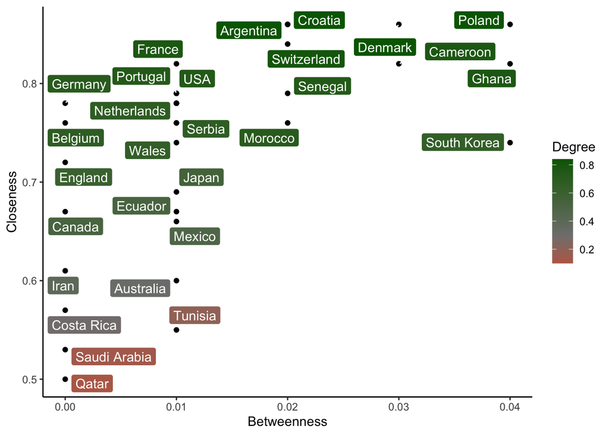

```r
#plotting
library(ggplot2)
library(ggrepel)
ggplot(DFCentrality, aes(x=Betweenness, y=Closeness)) +
    theme_classic() + geom_point() +
    geom_label_repel(aes(label=person,fill=Degree),color='white') +
    scale_fill_gradient2(low = "red", mid='grey50',high ="darkgreen",
                           midpoint = 0.3)
```